# Simple data analysis with Apache Spark

In this example we are going to use Apache Spark to perform distributed analysis on a CSV generated by our Python scrapping class. The goal of this program is mainly to clean data for further analysis down the line. At the end, however we will also show some MLlib alogrithms as well.

```python
# Do an initial test of Spark to make sure it works.
import findspark
findspark.init()
import pyspark
sc = pyspark.SparkContext('local[*]')
# do something to prove it works
rdd = sc.parallelize(range(1000))
rdd.takeSample(False, 5)
sc.stop()
```

Now that we have checked that PySpark is up and running let's start to do some processing using a csv file generated previously using fb_post.py (for instructions on using fb_scrapper please see the readme file). First we are going to read the CSV file into a data frame and filter out stop words and punctation.

```python
from pyspark.sql import SQLContext
from pyspark.sql.functions import regexp_replace, trim, col, lower
from pyspark.ml.feature import StopWordsRemover
from pyspark.ml.feature import Tokenizer
#Comment and uncomment the following line as necessary
#sc = pyspark.SparkContext('local[*]')
sqlContext = SQLContext(sc)
df = sqlContext.read.format('com.databricks.spark.csv').options(header='true', inferschema='true').load('160558090672531_facebook_statuses.csv')
df.show()
# Drop the null crap
df = df.na.drop(subset=["status_message"])
# Remove punctation from status messages
df2 = df.select(regexp_replace("status_message", "\p{Punct}", "").alias("status_message"), "status_id")
df2.show()
messages = df2
# Tokenize and remove stop words
tokenizer = Tokenizer(inputCol="status_message", outputCol="filtered")
filterw = tokenizer.transform(messages)
filterw.show()
remover = StopWordsRemover(inputCol="filtered", outputCol="filtered1")
filtered_final = remover.transform(filterw)
filtered_final.show()
messages = filtered_final.select("filtered1")
messages2 = filtered_final.select("status_id","status_message").rdd
# We will use this to create our inverted index later in the file
doc_index = messages2.collectAsMap()
#Convert to RDD
message_rdd=messages.rdd
```

```
+--------------------+--------------------+----------+-----------+--------------------+-------------------+-------------+------------+----------+---------+---------+--------+---------+--------+----------+
|           status_id|      status_message| link_name|status_type|         status_link|   status_published|num_reactions|num_comments|num_shares|num_likes|num_loves|num_wows|num_hahas|num_sads|num_angrys|
+--------------------+--------------------+----------+-----------+--------------------+-------------------+-------------+------------+----------+---------+---------+--------+---------+--------+----------+
|160558090672531_1...|So, rain is in th...|      null|     status|                null|2016-12-22 13:34:30|            4|          15|         0|        4|        0|       0|        0|       0|         0|
|160558090672531_1...|                null|      null|     status|                null|2016-12-22 21:38:02|           15|           3|         0|       14|        0|       1|        0|       0|         0|
|160558090672531_1...|              Zoomie|      null|      video|https://www.faceb...|2016-12-21 19:12:13|           55|          13|         4|       50|        0|       5|        0|       0|         0|
|160558090672531_1...|Someone don't see...|      null|      video|https://www.faceb...|2016-12-21 17:40:37|           34|           5|         3|       34|        0|       0|        0|       0|         0|
|160558090672531_1...|Know what would m...|      null|     status|                null|2016-12-21 09:51:47|           12|          13|         0|       12|        0|       0|        0|       0|         0|
|160558090672531_1...|                null|      null|      video|https://www.faceb...|2016-12-21 19:04:09|           19|           7|         3|       15|        0|       4|        0|       0|         0|
|160558090672531_1...|So, I plan on bei...|      null|     status|                null|2016-12-20 12:09:08|            4|           2|         0|        4|        0|       0|        0|       0|         0|
|160558090672531_1...|               Johno|      null|      video|https://www.faceb...|2016-12-21 18:25:39|           19|           1|         4|       19|        0|       0|        0|       0|         0|
|160558090672531_1...|        Shawn Malone|      null|      video|https://www.faceb...|2016-12-21 18:54:30|           14|           4|         1|       13|        1|       0|        0|       0|         0|
|160558090672531_1...|                null|      null|      video|https://www.faceb...|2016-12-21 18:58:56|           13|           8|         0|       13|        0|       0|        0|       0|         0|
|160558090672531_1...|Doopey, Mr. Magoo...|      null|      photo|https://www.faceb...|2016-12-21 18:35:29|            9|           0|         0|        9|        0|       0|        0|       0|         0|
|160558090672531_1...|          Chris King|      null|      video|https://www.faceb...|2016-12-21 17:53:35|           13|           4|         0|       13|        0|       0|        0|       0|         0|
|160558090672531_1...|we needed more sa...|      null|      photo|https://www.faceb...|2016-12-21 18:25:58|           11|           0|         0|       11|        0|       0|        0|       0|         0|
|160558090672531_1...|        safety break|      null|      photo|https://www.faceb...|2016-12-21 18:25:12|            5|           0|         0|        5|        0|       0|        0|       0|         0|
|160558090672531_1...|Small group of li...|      null|      video|https://www.faceb...|2016-12-21 18:16:21|           15|           0|         0|       15|        0|       0|        0|       0|         0|
|160558090672531_1...|    Mr. Randy Barnes|      null|      video|https://www.faceb...|2016-12-21 17:59:13|           17|           0|         0|       17|        0|       0|        0|       0|         0|
|160558090672531_1...|Just dropped on t...|ThreeWaves|      photo|https://www.faceb...|2016-12-21 16:27:25|            2|           0|         0|        2|        0|       0|        0|       0|         0|
|160558090672531_1...|Thinking of bring...|      null|     status|                null|2016-12-20 14:45:04|            2|          10|         0|        2|        0|       0|        0|       0|         0|
|160558090672531_1...|                null|      null|     status|                null|2016-12-21 11:28:42|           32|           6|         0|       31|        1|       0|        0|       0|         0|
|160558090672531_1...|When you're tryin...|      null|      video|https://www.faceb...|2016-12-20 11:40:42|          104|          16|         3|       99|        0|       2|        3|       0|         0|
+--------------------+--------------------+----------+-----------+--------------------+-------------------+-------------+------------+----------+---------+---------+--------+---------+--------+----------+
only showing top 20 rows

+--------------------+--------------------+
|      status_message|           status_id|
+--------------------+--------------------+
|So rain is in the...|160558090672531_1...|
|              Zoomie|160558090672531_1...|
|Someone dont see ...|160558090672531_1...|
|Know what would m...|160558090672531_1...|
|So I plan on bein...|160558090672531_1...|
|               Johno|160558090672531_1...|
|        Shawn Malone|160558090672531_1...|
|Doopey Mr Magoo a...|160558090672531_1...|
|          Chris King|160558090672531_1...|
|we needed more sa...|160558090672531_1...|
|        safety break|160558090672531_1...|
```

[output cut: 48 more lines]

```
|Doopey Mr Magoo a...|160558090672531_1...|[doopey, mr, mago...|[doopey, mr, mago...|
|          Chris King|160558090672531_1...|       [chris, king]|       [chris, king]|
|we needed more sa...|160558090672531_1...|[we, needed, more...|    [needed, safety]|
|        safety break|160558090672531_1...|     [safety, break]|     [safety, break]|
|Small group of li...|160558090672531_1...|[small, group, of...|[small, group, li...|
|     Mr Randy Barnes|160558090672531_1...| [mr, randy, barnes]| [mr, randy, barnes]|
|Just dropped on t...|160558090672531_1...|[just, dropped, o...|[dropped, link, k...|
|Thinking of bring...|160558090672531_1...|[thinking, of, br...|[thinking, bringi...|
|When youre trying...|160558090672531_1...|[when, youre, try...|[youre, trying, g...|
|httpsyoutube21g5b...|160558090672531_1...|[httpsyoutube21g5...|[httpsyoutube21g5...|
|httpsyoutubeDiCyd...|160558090672531_1...|[httpsyoutubedicy...|[httpsyoutubedicy...|
|one of the best o...|160558090672531_1...|[one, of, the, be...|[one, best, open,...|
|Move pretty damn ...|160558090672531_1...|[move, pretty, da...|[move, pretty, da...|
+--------------------+--------------------+--------------------+--------------------+
only showing top 20 rows
```

Now we are going to do a simple word count with the rdd that we just created and generate a graph of the top words.

```
The top words are:
boat: 169
anyone: 144
one: 116
get: 93
canoe: 91
im: 91
like: 87
ocoee: 82
```

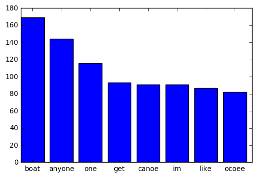

```python
# WordCount with RDD. Normally this would be used in conjunction with NLP to extract trending topics.
from operator import add
import matplotlib.pyplot as plt
import numpy as np
def plot_histogram(indexes, values):
    indexes2 = np.arange(len(indexes))
    values = np.asarray(values)
    plt.bar(indexes2, values)
    bar_width = 2
    plt.xticks(indexes2 + bar_width*.2, indexes)
    plt.show()
# Prints the WordCount of words that appear more than 25 times and appends them to indexes and values.
def print_word_count(output, indexes, values):
    for (word, count) in output:
        if count > 25 and word is not "":
            # append to indexes
            indexes.append(word)
            values.append(count)
            print("%s: %i" % (word, count))



statuses = message_rdd.flatMap(lambda x: x)
words = statuses.flatMap(lambda x: x)
#se = statuses.flatMap(String)
counts = words.flatMap(lambda x: x.split(' ')) \
                  .map(lambda x: (x, 1)) \
                  .reduceByKey(add)


output1 = counts.sortByKey().collectAsMap()
wordsMap = counts.collectAsMap()
#ouput1.saveAsTextFile("keys.txt")
# Get just the most popular words
output = counts.takeOrdered(9, key = lambda x: -x[1])
indexes = []
values = []
print("The top words are:")
print_word_count(output, indexes, values)
plot_histogram(indexes,values)
```

### Create a document index and an inverted index

Now that we have done some simple procesing lets get into the meat of this notebook. We are going to create an inverted index using MR.

```python
def make_document_index(raw_status):
    status = raw_status.flatMap(lambda x : x)
    doc_index = status.zipWithIndex()
    doc_index = doc_index.map(lambda y: (y[1], y[0])).collectAsMap()
    return doc_index
def inverted_index(documents):
    #Invert to (status_id, terms[]) and then flatMapValues in order to get (status_id, term)
    documents = documents.map(lambda x: (x[1],x[0])).flatMapValues(lambda x: x)
    #Undo to (term, status_id) and reduce to get (term, status_ids[])
    documents = documents.map(lambda x: (x[1],[x[0]])).reduceByKey(lambda a,b: a+b)
    print("inverted index sucessfully created")
    return documents
messages = filtered_final.select("filtered1","status_id").rdd
status_inverted_index = inverted_index(messages)
inverted_map = status_inverted_index.collectAsMap()
```

```
inverted index sucessfully created
```

```python
# Load file
def get_word_count(some_dict, aRDD):
    return aRDD.filter(lambda x: x in list(some_dict.keys())).map(lambda key: (key, some_dict[key]))
names = sc.textFile("rivers.txt")
riverNames = names.flatMap(lambda x: x.split("\n"))
r = get_word_count(wordsMap, riverNames)
#r = riverNames.filter(lambda x : x in list(wordsMap.keys())).map(lambda key: (key, wordsMap[key]))
r.collect()
```

```
[('tellico', 24), ('ocoee', 82)]
```

We will now be doing some interactive analysis with iPython widgets. (Note this will not necessarily render in GitHub, but if you download the notebook you should be able to see it).

```python
# Let's try to make things a little more interactive
from ipywidgets import interact, interactive, fixed
import ipywidgets as widgets
from IPython.display import display
value_search = widgets.Text()
display(value_search)
value_search2 = widgets.Text()
display(value_search2)

def find_key(sender):
    text = value_search.value
    if text in output1:
        print(text + " occurs " + str(output1[text]) + " times in the file")
# Todo clean up sloppy method
def mini_search(sender):
    text = value_search2.value.strip(" ")
    if text in inverted_map:
        l = inverted_map[text]
        for i in l:
            if i in doc_index:
                l = i
                print(doc_index[i])
value_search.on_submit(find_key)
value_search2.on_submit(mini_search)
```

Now we are going to generate a WordCloud.

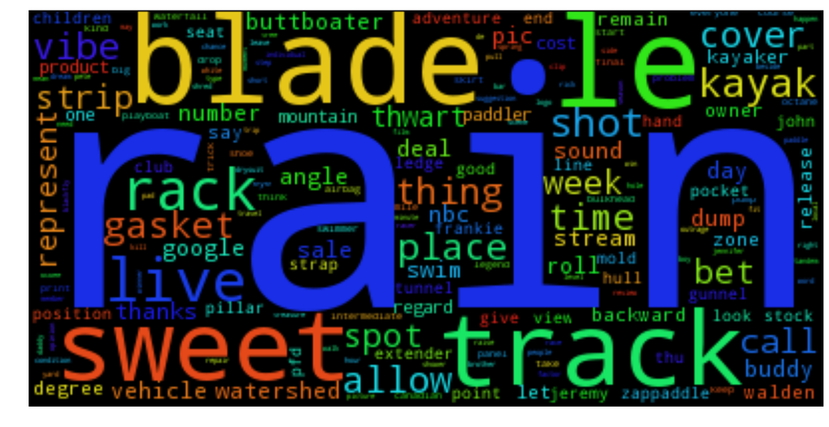

```python
#Wordcloud example
import matplotlib.pyplot as plt
from wordcloud import WordCloud, STOPWORDS
def makeWordCloud(words):
    stopwords = set(STOPWORDS)
    stopwords.add("thank")
    wordcloud = WordCloud(stopwords=stopwords, background_color='black').generate(" ".join(wordlist))
    plt.figure(figsize=(15,10))
    plt.imshow(wordcloud)
    plt.axis('off')
    plt.show()
wordlist = output1.keys()
makeWordCloud(words)
```

```python
# Filter to extract known names of rivers and get useful URLS
df2 = df.na.drop(subset=["status_link"])
df3 = df2.select("status_link")
df2.show()
```

```
+--------------------+--------------------+--------------------+-----------+--------------------+-------------------+-------------+------------+----------+---------+---------+--------+---------+--------+----------+
|           status_id|      status_message|           link_name|status_type|         status_link|   status_published|num_reactions|num_comments|num_shares|num_likes|num_loves|num_wows|num_hahas|num_sads|num_angrys|
+--------------------+--------------------+--------------------+-----------+--------------------+-------------------+-------------+------------+----------+---------+---------+--------+---------+--------+----------+
|160558090672531_1...|              Zoomie|                null|      video|https://www.faceb...|2016-12-21 19:12:13|           55|          13|         4|       50|        0|       5|        0|       0|         0|
|160558090672531_1...|Someone don't see...|                null|      video|https://www.faceb...|2016-12-21 17:40:37|           34|           5|         3|       34|        0|       0|        0|       0|         0|
|160558090672531_1...|               Johno|                null|      video|https://www.faceb...|2016-12-21 18:25:39|           19|           1|         4|       19|        0|       0|        0|       0|         0|
|160558090672531_1...|        Shawn Malone|                null|      video|https://www.faceb...|2016-12-21 18:54:30|           14|           4|         1|       13|        1|       0|        0|       0|         0|
|160558090672531_1...|Doopey, Mr. Magoo...|                null|      photo|https://www.faceb...|2016-12-21 18:35:29|            9|           0|         0|        9|        0|       0|        0|       0|         0|
|160558090672531_1...|          Chris King|                null|      video|https://www.faceb...|2016-12-21 17:53:35|           13|           4|         0|       13|        0|       0|        0|       0|         0|
|160558090672531_1...|we needed more sa...|                null|      photo|https://www.faceb...|2016-12-21 18:25:58|           11|           0|         0|       11|        0|       0|        0|       0|         0|
|160558090672531_1...|        safety break|                null|      photo|https://www.faceb...|2016-12-21 18:25:12|            5|           0|         0|        5|        0|       0|        0|       0|         0|
|160558090672531_1...|Small group of li...|                null|      video|https://www.faceb...|2016-12-21 18:16:21|           15|           0|         0|       15|        0|       0|        0|       0|         0|
|160558090672531_1...|    Mr. Randy Barnes|                null|      video|https://www.faceb...|2016-12-21 17:59:13|           17|           0|         0|       17|        0|       0|        0|       0|         0|
|160558090672531_1...|Just dropped on t...|          ThreeWaves|      photo|https://www.faceb...|2016-12-21 16:27:25|            2|           0|         0|        2|        0|       0|        0|       0|         0|
|160558090672531_1...|When you're tryin...|                null|      video|https://www.faceb...|2016-12-20 11:40:42|          104|          16|         3|       99|        0|       2|        3|       0|         0|
|160558090672531_1...|https://youtu.be/...| Hope Diamond Shines|      video|https://youtu.be/...|2016-12-20 21:30:28|            3|           3|         0|        3|        0|       0|        0|       0|         0|
|160558090672531_1...|https://youtu.be/...|          Rio de Oro|      video|https://youtu.be/...|2016-12-20 21:53:39|            2|           1|         1|        2|        0|       0|        0|       0|         0|
|160558090672531_1...|one of the best o...|   December 19, 2016|      photo|https://www.faceb...|2016-12-19 17:27:57|           34|          13|         1|       32|        2|       0|        0|       0|         0|
|160558090672531_1...|Move pretty damn ...|                null|      video|https://www.faceb...|2016-12-20 17:53:07|           22|           3|         1|       22|        0|       0|        0|       0|         0|
|160558090672531_1...|how many of you h...|                null|      video|https://www.faceb...|2016-12-20 05:15:55|           17|           8|         2|       17|        0|       0|        0|       0|         0|
|160558090672531_1...|big foot, Psyco, ...|Photos from Micha...|      photo|https://www.faceb...|2016-12-20 17:15:04|            4|           0|         1|        4|        0|       0|        0|       0|         0|
|160558090672531_1...|This one is for y...|   December 20, 2016|      photo|https://www.faceb...|2016-12-20 05:21:01|           18|           3|         0|       18|        0|       0|        0|       0|         0|
|160558090672531_1...|Don't let a buttb...|   Dirt Bag Paddlers|      photo|https://www.faceb...|2016-12-19 14:20:25|           10|           3|         0|       10|        0|       0|        0|       0|         0|
+--------------------+--------------------+--------------------+-----------+--------------------+-------------------+-------------+------------+----------+---------+---------+--------+---------+--------+----------+
only showing top 20 rows
```

Okay so now we want to get the images and or videos. Uses for the images might include image search for our database (with the river extracted using NLP) or computer vision applications.

```python
#Now let's try to use these urls to get their the respective images or videos
from pyspark.sql import SparkSession
from lxml import html
import requests
from IPython.display import Image
spark = SparkSession \
    .builder \
    .appName("Python Spark SQL basic example") \
    .config("spark.some.config.option", "some-value") \
    .getOrCreate()
df2.createOrReplaceTempView("posts")
sqlDF = spark.sql("SELECT * FROM posts WHERE status_link LIKE '%photo%'")
sqlDF.show()
statusRDD = sqlDF.select('status_link').rdd
urls = statusRDD.flatMap(lambda x: x)
print(urls.take(3))
#Now let's save the images possibly for a Computer Vision application
urls2 = urls.collect()

#for url in urls2:
    #page = requests.get(url)
    #tree = html.fromstring(page.content)
    #imageUrl = tree.xpath('//img[@class="spotlight"]/@src')
```

```
+--------------------+--------------------+--------------------+-----------+--------------------+-------------------+-------------+------------+----------+---------+---------+--------+---------+--------+----------+
|           status_id|      status_message|           link_name|status_type|         status_link|   status_published|num_reactions|num_comments|num_shares|num_likes|num_loves|num_wows|num_hahas|num_sads|num_angrys|
+--------------------+--------------------+--------------------+-----------+--------------------+-------------------+-------------+------------+----------+---------+---------+--------+---------+--------+----------+
|160558090672531_1...|Doopey, Mr. Magoo...|                null|      photo|https://www.faceb...|2016-12-21 18:35:29|            9|           0|         0|        9|        0|       0|        0|       0|         0|
|160558090672531_1...|we needed more sa...|                null|      photo|https://www.faceb...|2016-12-21 18:25:58|           11|           0|         0|       11|        0|       0|        0|       0|         0|
|160558090672531_1...|        safety break|                null|      photo|https://www.faceb...|2016-12-21 18:25:12|            5|           0|         0|        5|        0|       0|        0|       0|         0|
|160558090672531_1...|Just dropped on t...|          ThreeWaves|      photo|https://www.faceb...|2016-12-21 16:27:25|            2|           0|         0|        2|        0|       0|        0|       0|         0|
|160558090672531_1...|one of the best o...|   December 19, 2016|      photo|https://www.faceb...|2016-12-19 17:27:57|           34|          13|         1|       32|        2|       0|        0|       0|         0|
|160558090672531_1...|big foot, Psyco, ...|Photos from Micha...|      photo|https://www.faceb...|2016-12-20 17:15:04|            4|           0|         1|        4|        0|       0|        0|       0|         0|
|160558090672531_1...|This one is for y...|   December 20, 2016|      photo|https://www.faceb...|2016-12-20 05:21:01|           18|           3|         0|       18|        0|       0|        0|       0|         0|
|160558090672531_1...|Don't let a buttb...|   Dirt Bag Paddlers|      photo|https://www.faceb...|2016-12-19 14:20:25|           10|           3|         0|       10|        0|       0|        0|       0|         0|
|160558090672531_1...|Can't believe it ...|                null|      photo|https://www.faceb...|2016-12-20 04:33:20|            7|           0|         0|        7|        0|       0|        0|       0|         0|
|160558090672531_1...|Canoe army unite ...|   Dirt Bag Paddlers|      photo|https://www.faceb...|2016-12-19 15:31:48|           11|           2|         0|       11|        0|       0|        0|       0|         0|
|160558090672531_1...|I have a second G...|                null|      photo|https://www.faceb...|2016-12-13 11:40:39|           20|           7|         3|       20|        0|       0|        0|       0|         0|
|160558090672531_1...|          Yeah... 😎|                null|      photo|https://www.faceb...|2016-12-18 09:44:30|           54|           3|         6|       50|        3|       0|        1|       0|         0|
|160558090672531_1...|Santellia may run...|                null|      photo|https://www.faceb...|2016-12-18 04:49:31|            5|          12|         0|        5|        0|       0|        0|       0|         0|
|160558090672531_1...|      New shirt idea|          Custom.inc|      photo|https://www.faceb...|2016-12-17 20:30:27|            2|           0|         0|        2|        0|       0|        0|       0|         0|
|160558090672531_1...|              🔥🔥🔥|     Gnarlz Outdoors|      photo|https://www.faceb...|2016-12-16 17:38:46|           27|           3|         1|       27|        0|       0|        0|       0|         0|
|160558090672531_1...|I was reading thr...|                null|      photo|https://www.faceb...|2016-12-14 09:27:05|           64|           8|         3|       54|        7|       0|        3|       0|         0|
|160558090672531_8...|                Oops|                null|      photo|https://www.faceb...|2015-03-22 18:51:01|           56|          30|         3|       56|        0|       0|        0|       0|         0|
|160558090672531_1...|Sideways boof. St...|               Shawn|      photo|https://www.faceb...|2016-12-13 19:08:42|           12|           3|         0|       12|        0|       0|        0|       0|         0|
|160558090672531_1...|   John Baron Duncan|                null|      photo|https://www.faceb...|2016-12-13 19:27:41|            7|           0|         0|        7|        0|       0|        0|       0|         0|
|160558090672531_1...|See I thought I w...|Molly Wolff Photo...|      photo|https://www.faceb...|2016-12-13 10:59:34|           38|           4|         0|       35|        0|       2|        1|       0|         0|
+--------------------+--------------------+--------------------+-----------+--------------------+-------------------+-------------+------------+----------+---------+---------+--------+---------+--------+----------+
only showing top 20 rows

['https://www.facebook.com/photo.php?fbid=10211584727843701&set=gm.1312647978796864&type=3', 'https://www.facebook.com/photo.php?fbid=10211584645601645&set=gm.1312638645464464&type=3', 'https://www.facebook.com/photo.php?fbid=10211584638241461&set=gm.1312638268797835&type=3']
```

## Latent Dirichlet allocation

We are now going to construct a topic model using an algorithm called LDA. You can find out more information on LDA [here.](https://en.wikipedia.org/wiki/Latent_Dirichlet_allocation) Our real goal is to get a set of topics for each document. These topic can them used to classify documents into sub-categories or themes. This will then be used in our search engine later on or for other analytics purposes. Unfortunately, at this point the PySpark LDA model is not all that useful for data analysis purposes but we will keep it around in the code anyways. (Note if anyone knows an easy way of visualizing a PySpark LDA model with pyLDAvis let me know!).

```python
# This section remains buggy and prone to jams run at your own risk!
from pyspark.mllib.clustering import LDA, LDAModel
from pyspark.mllib.feature import IDF
from pyspark.ml.feature import CountVectorizer
from pyspark.mllib.linalg import Vectors
#vectorize tags array for each user
vectorizer = CountVectorizer(inputCol="filtered1", outputCol="features").fit(filtered_final)
countVectors = vectorizer.transform(filtered_final).select("status_id", "features")
countVectors.show()
#find TF-IDF coefficients for each tag
print("begin")
frequencyVectors = countVectors.rdd.map(lambda vector: vector[1])
frequencyDenseVectors = frequencyVectors.map(lambda vector: Vectors.dense(vector))
idf = IDF().fit(frequencyDenseVectors)
print('fitting complete')
tfidf = idf.transform(frequencyDenseVectors)
print("tf idf complete")
#prepare corpus for LDA
corpus = tfidf.map(lambda x: [1, x]).cache()
print("entering lda phase")
#train LDA
ldaModel = LDA.train(corpus, k = 15, maxIterations=100, optimizer="online", docConcentration=2.0, topicConcentration=3.0)
print("lda model complete")
```

```
+--------------------+--------------------+
|           status_id|            features|
+--------------------+--------------------+
|160558090672531_1...|(4709,[2,4,7,9,14...|
|160558090672531_1...| (4709,[3791],[1.0])|
|160558090672531_1...|(4709,[20,25,43,4...|
|160558090672531_1...|(4709,[3,9,12,28,...|
|160558090672531_1...|(4709,[2,92,154,2...|
|160558090672531_1...| (4709,[4704],[1.0])|
|160558090672531_1...|(4709,[530,2881],...|
|160558090672531_1...|(4709,[521,527,15...|
|160558090672531_1...|(4709,[253,260],[...|
|160558090672531_1...|(4709,[514,764],[...|
|160558090672531_1...|(4709,[381,514],[...|
|160558090672531_1...|(4709,[7,129,170,...|
|160558090672531_1...|(4709,[527,763,12...|
|160558090672531_1...|(4709,[253,742,10...|
|160558090672531_1...|(4709,[0,6,10,24,...|
|160558090672531_1...|(4709,[0,36,104,1...|
|160558090672531_1...| (4709,[3983],[1.0])|
|160558090672531_1...| (4709,[3926],[1.0])|
|160558090672531_1...|(4709,[1,3,26,69,...|
|160558090672531_1...|(4709,[30,231,233...|
+--------------------+--------------------+
only showing top 20 rows

begin
fitting complete
tf idf complete
entering lda phase
```

```python
#ldaModel.save(sc, "ldaModel")
from operator import itemgetter
topics = ldaModel.topicsMatrix()
#for topic in range(3):
    #print("Topic " + str(topic) + ":")
    #for word in range(0, ldaModel.vocabSize()):
        #print(" " + str(topics[word][topic]))
# Now lets get the words back
topicIndices = ldaModel.describeTopics(maxTermsPerTopic=5)
vocablist = vectorizer.vocabulary
topicsRDD = sc.parallelize(topicIndices)
termsRDD = topicsRDD.map(lambda topic: (zip(itemgetter(*topic[0])(vocablist), topic[1])))

indexedTermsRDD = termsRDD.zipWithIndex()
termsRDD = indexedTermsRDD.flatMap(lambda term: [(t[0], t[1], term[1]) for t in term[0]])
termDF = termsRDD.toDF(['term', 'probability', 'topicId'])
termDF.orderBy('topicID').show()
```

```
+----------+--------------------+-------+
|      term|         probability|topicId|
+----------+--------------------+-------+
|          |0.002115260722177052|      0|
|outfitting|0.002082394032980986|      0|
| condition|0.002233789998397361|      0|
|      sale|0.001751120910836...|      0|
|      bags|  0.0039045116955342|      0|
|      left|0.002958445989501369|      1|
|       dry|0.003085064387193...|      1|
|     right|0.006624683678297395|      1|
|      bank|0.003388931845333321|      1|
|      said|0.003386598220352003|      1|
|        xl|8.867720745763356E-4|      2|
|     kinda|9.783993162960018E-4|      2|
|       dad|0.001508739022845...|      2|
|      yall|0.001684071699308...|      2|
|       got|0.001003047322064...|      2|
|      made|0.001074434286731...|      3|
|      rich|0.001250121524622...|      3|
|     video|0.004485848624344074|      3|
|     moore|0.001177269382172...|      3|
|         8|0.001054212003362...|      3|
+----------+--------------------+-------+
only showing top 20 rows
```

```python
spark = SparkSession \
    .builder \
    .appName("Python Spark SQL basic example") \
    .config("spark.some.config.option", "some-value") \
    .getOrCreate()
t2 = termDF

t2.createOrReplaceTempView("topics")

terms=spark.sql("SELECT * FROM topics WHERE probability>.0001")
terms.show()
```

```
+----------+--------------------+-------+
|      term|         probability|topicId|
+----------+--------------------+-------+
|      bags|  0.0039045116955342|      0|
| condition|0.002233789998397361|      0|
|          |0.002115260722177052|      0|
|outfitting|0.002082394032980986|      0|
|      sale|0.001751120910836...|      0|
|     right|0.006624683678297395|      1|
|      bank|0.003388931845333321|      1|
|      said|0.003386598220352003|      1|
|       dry|0.003085064387193...|      1|
|      left|0.002958445989501369|      1|
|      yall|0.001684071699308...|      2|
|       dad|0.001508739022845...|      2|
|       got|0.001003047322064...|      2|
|     kinda|9.783993162960018E-4|      2|
|        xl|8.867720745763356E-4|      2|
|     video|0.004485848624344074|      3|
|      rich|0.001250121524622...|      3|
|     moore|0.001177269382172...|      3|
|      made|0.001074434286731...|      3|
|         8|0.001054212003362...|      3|
+----------+--------------------+-------+
only showing top 20 rows
```

```python
import pyLDAvis
import pyLDAvis.graphlab
import graphlab as gl
pyLDAvis.prepare(ldaModel.topicsMatrix(),vocabList,)
```

# Word2Vec Example

Here is a basic example of using PySpark's Word2Vec library.

```python
from pyspark.ml.feature import Word2Vec
from pyspark.sql import SparkSession


# Learn a mapping from words to Vectors.
word2Vec = Word2Vec(vectorSize=3, minCount=0, inputCol="filtered1", outputCol="result")
model = word2Vec.fit(filtered_final)
result = model.transform(filtered_final)
for feature in result.select("result").take(3):
    print(feature)

topN = 13
synonymsDF = model.findSynonyms('boat', topN).toPandas()
synonymsDF
synonymsDF = model.findSynonyms('whitewater', topN).toPandas()
synonymsDF
```

```
Row(result=DenseVector([-0.0984, -0.0612, -0.0048]))
Row(result=DenseVector([-0.1532, -0.0619, 0.1014]))
Row(result=DenseVector([-0.0846, -0.0368, 0.0125]))
```

|  | word | similarity |
| --- | --- | --- |
| 0 | nrs | 0.999952 |
| 1 | squirt | 0.999488 |
| 2 | develop | 0.998881 |
| 3 | finish | 0.997412 |
| 4 | components | 0.997369 |
| 5 | 244 | 0.997068 |
| 6 | orr | 0.997018 |
| 7 | everything | 0.996642 |
| 8 | legged | 0.996259 |
| 9 | lunchtime | 0.996152 |
| 10 | obvious | 0.996109 |
| 11 | 😋 | 0.995716 |
| 12 | radar | 0.995314 |

# Further Processing

Another useful thing to do before building a Word2Vec model is stemming and (depending on the model) tagging. We can accomplish this with NLTK.

```python
# More Natural Language Processing using NLP. Lemmatization, Chunking, and Tagging.
import nltk
from nltk.stem.wordnet import WordNetLemmatizer
messages = filtered_final.select("filtered")
message_rdd=messages.rdd
message_rdd = message_rdd.flatMap(lambda x:x)
print(message_rdd.first())
pos_statuses = message_rdd.map(nltk.pos_tag)
print(pos_statuses.take(5))
# Todo get lemmatization working
```

```
['so', 'rain', 'is', 'in', 'the', 'forecast', 'for', 'saturday', 'and', 'saturday', 'night', 'which', 'means', 'we', 'may', 'get', 'some', 'natural', 'flow', 'for', 'christmas', 'would', 'anyone', 'be', 'down', 'to', 'paddle', 'if', 'that', 'happens', 'like', 'little', 'or', 'tellico', 'or', 'someth…
[[('so', 'RB'), ('rain', 'NN'), ('is', 'VBZ'), ('in', 'IN'), ('the', 'DT'), ('forecast', 'NN'), ('for', 'IN'), ('saturday', 'JJ'), ('and', 'CC'), ('saturday', 'JJ'), ('night', 'NN'), ('which', 'WDT'), ('means', 'VBZ'), ('we', 'PRP'), ('may', 'MD'), ('get', 'VB'), ('some', 'DT'), ('natural', 'JJ'), (…
```